Lake Name: Eaton Brook Reservoir

Lake acreage: 274.6

County: MADISON

PWLID: 0602-0041

Waterbody Classification: B

Coordinates: 42.8591,-75.698998

Is this waterbody a public water supply: No

Are there DOH desingated beaches on this waterbody: No

Open Water Indicators

2018 Sampling Results

Seasonal Change

06-17

07-01

07-15

07-30

08-16

08-27

09-11

09-24

Clarity (m)

5.75

6.35

5.25

5.05

4.65

4.90

5.20

7.40

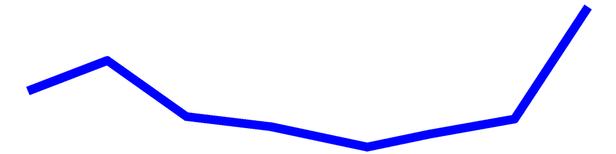

Surface TP (mg/L)

0.01

0.01

0.01

0.00

0.01

0.01

0.01

0.01

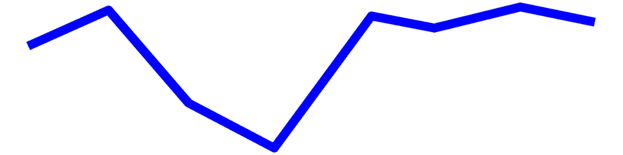

Surface TDP (mg/L)

0.00

0.00

0.00

0.00

0.00

0.01

0.01

0.01

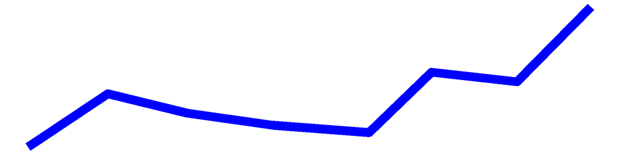

Deep TP (mg/L)

0.01

0.01

0.03

0.01

0.02

0.02

0.05

0.05

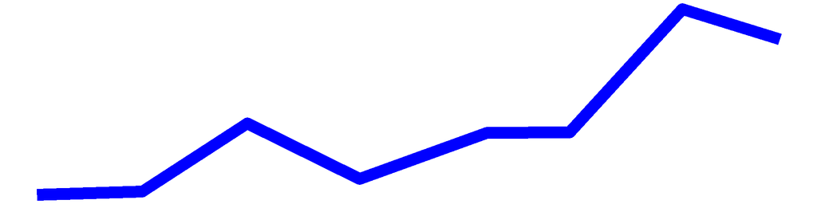

Deep TDP (mg/L)

0.01

0.00

0.01

0.01

0.01

0.01

0.01

0.01

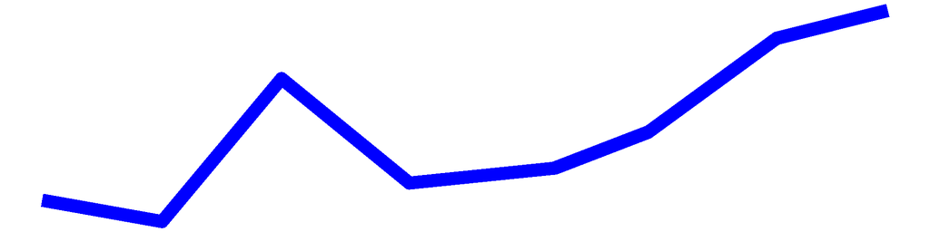

TN (mg/L)

0.44

0.44

0.26

0.30

0.25

0.22

0.46

0.28

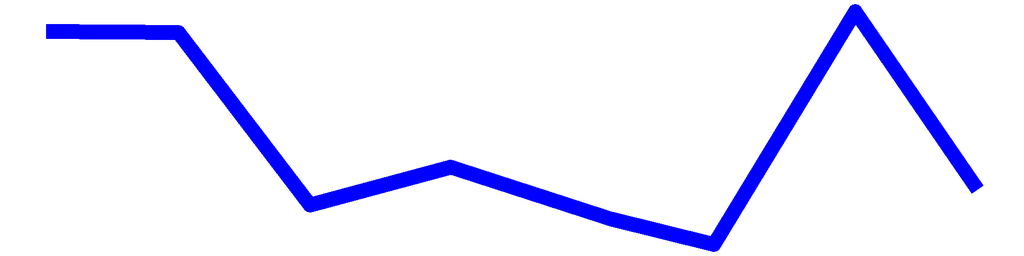

TDN (mg/L)

0.44

0.44

0.28

0.29

0.26

0.23

0.48

0.28

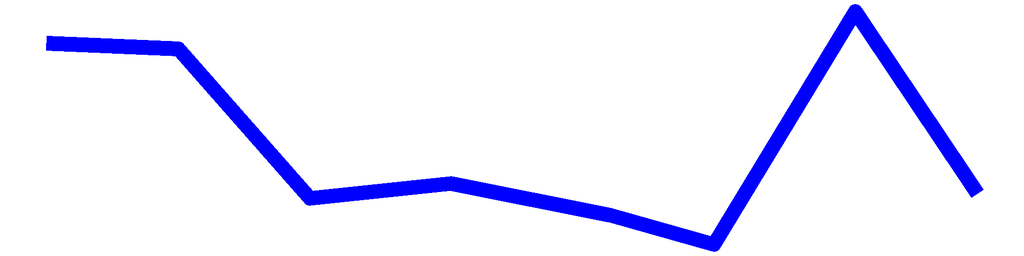

TN:TP

59.01

50.62

47.39

74.83

29.37

27.62

52.49

33.70

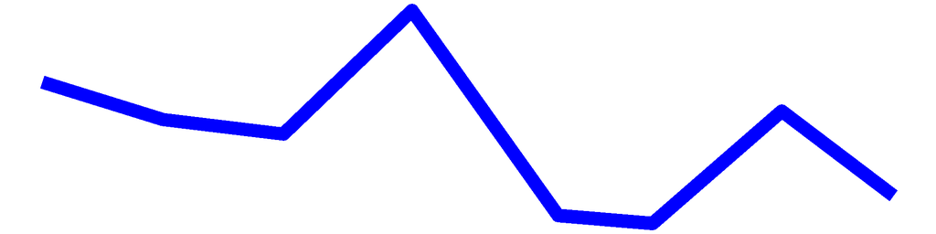

Surface NH3 (mg/L)

0.04

0.03

0.03

0.00

0.10

0.01

0.02

0.02

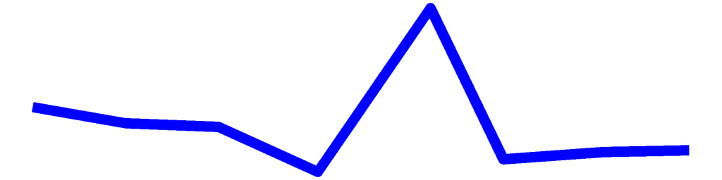

Deep NH3 (mg/L)

0.05

0.19

0.10

0.13

0.19

0.27

0.29

0.30

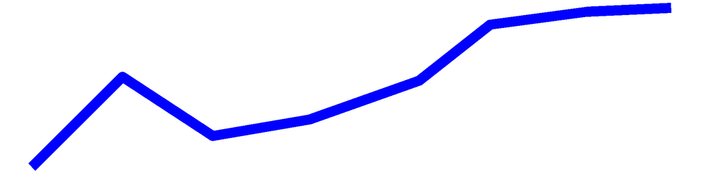

Chl.a (ug/L)

1.10

2.50

2.10

1.60

2.40

2.50

1.60

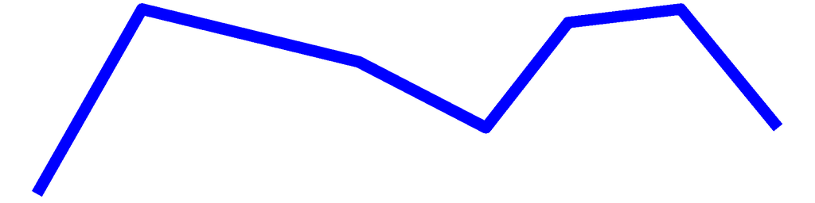

pH

7.42

8.00

7.32

7.17

7.77

7.71

6.27

7.58

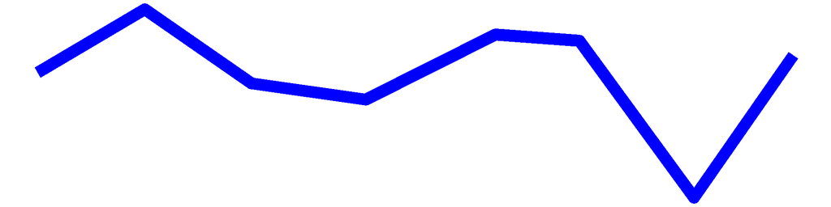

Cond (umho/cm)

143.00

151.30

148.00

138.90

139.10

134.30

127.90

149.60

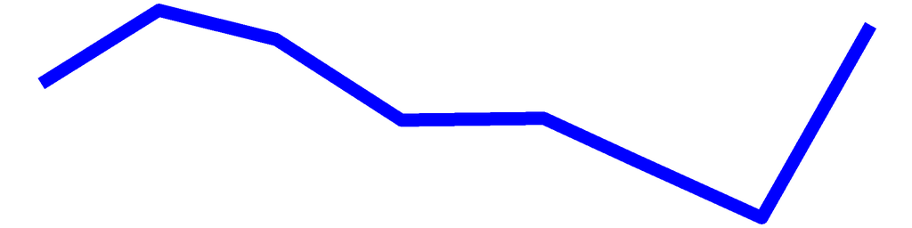

Surface Calcium (mg/L)

Bottom Calcium (mg/L)

Surface Chloride (mg/L)

5.00

5.00

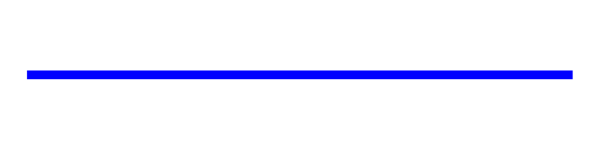

Bottom Chloride (mg/L)

Upper Temp (degC)

22.00

26.00

27.00

26.00

25.00

22.50

20.00

20.00

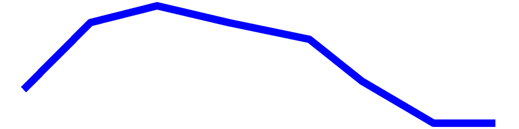

Deep Temp (degC)

14.00

14.00

14.00

14.00

11.00

11.00

11.00

11.00

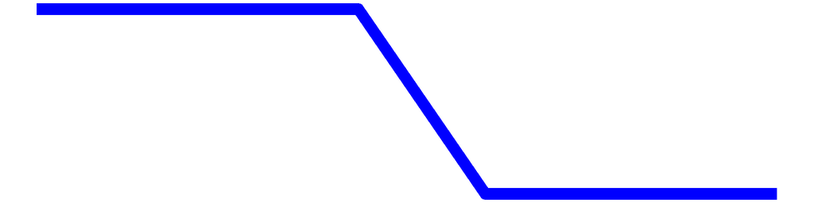

FP BG Chl.a (ug/L)

0.72

1.73

2.18

2.30

3.20

1.92

1.08

2.55

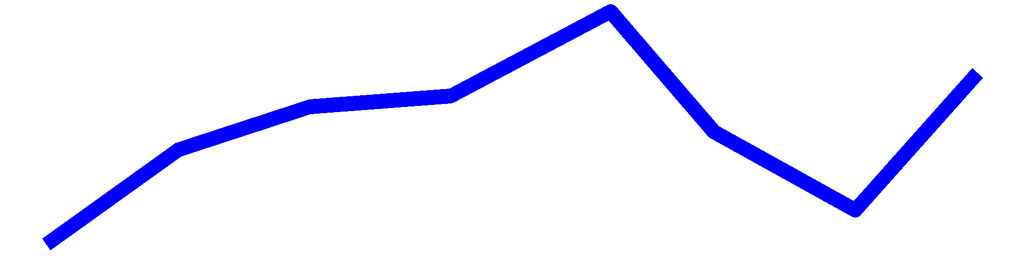

## Eaton Brook Reservoir – Sampling Season Results

### HABs Status

#### Open Water Algae

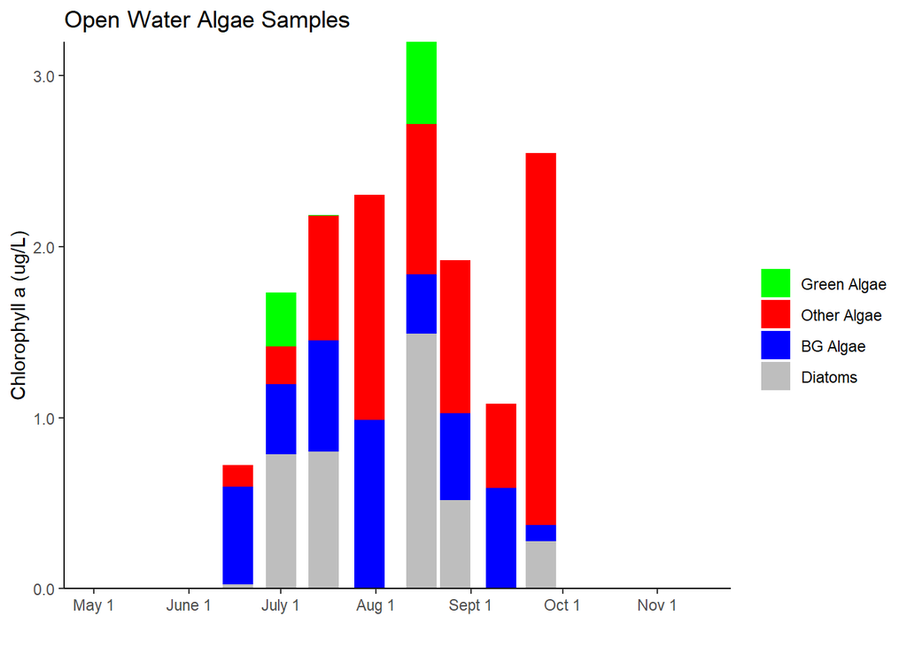

## Eaton Brook Reservoir Long-Term Trend Analysis

#### Clarity

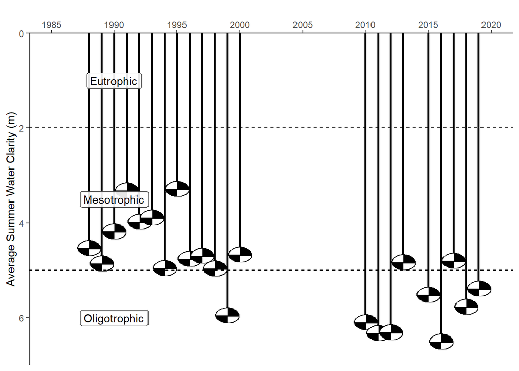

#### Chlorophyll *a*

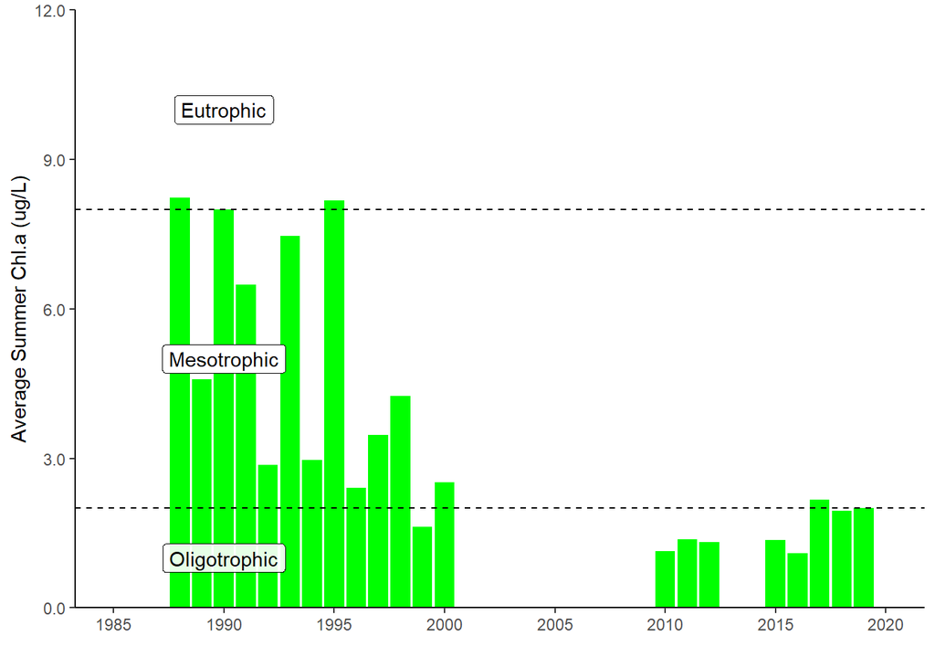

#### Surface and Deep Phosphorus

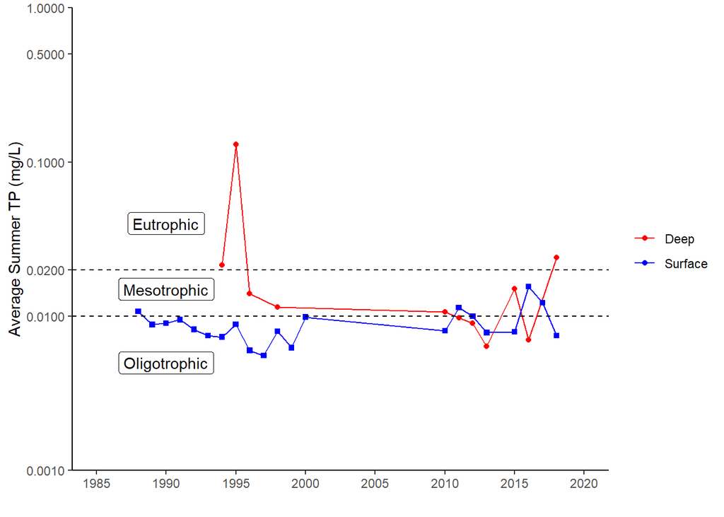

#### Nitrogen

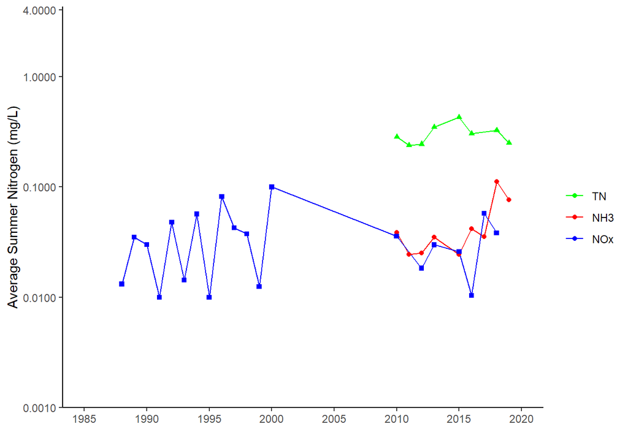

#### TN : TP

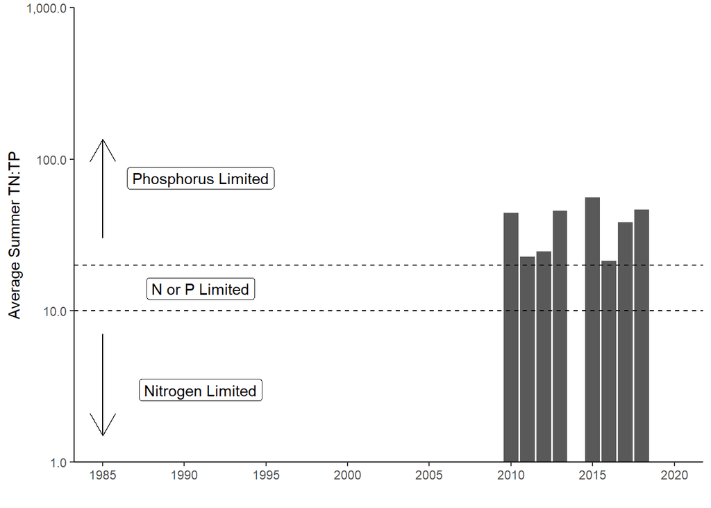

#### pH

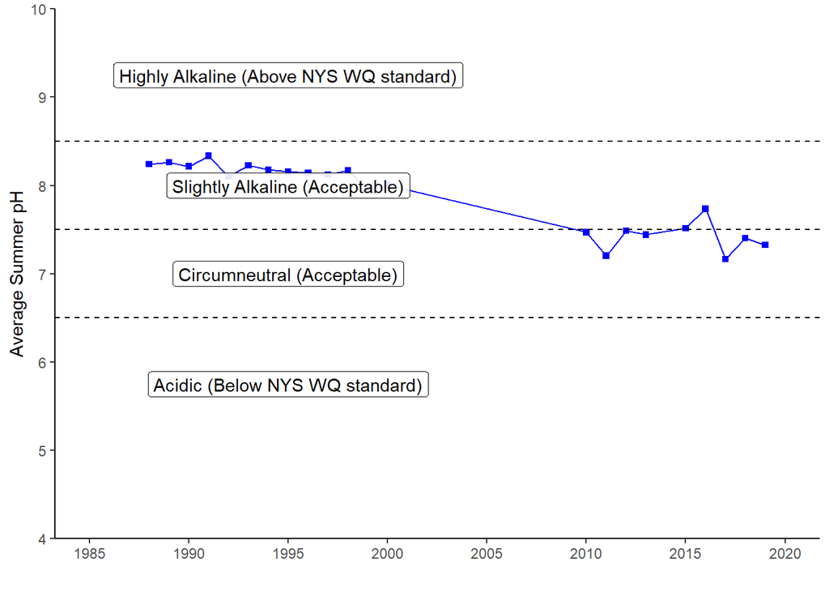

#### Specific Conductance

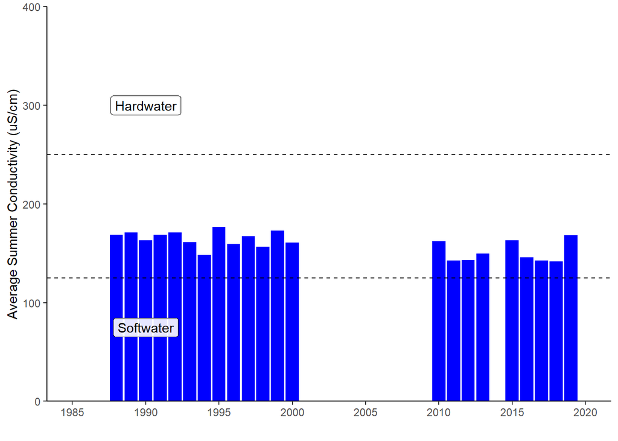

#### Calcium

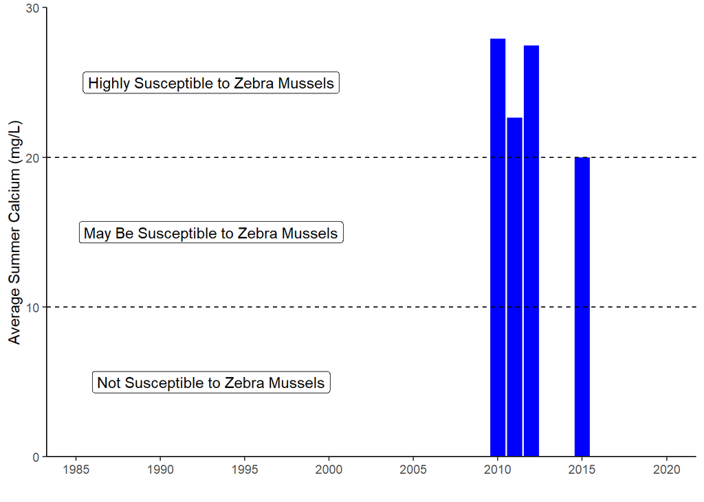

#### Chloride

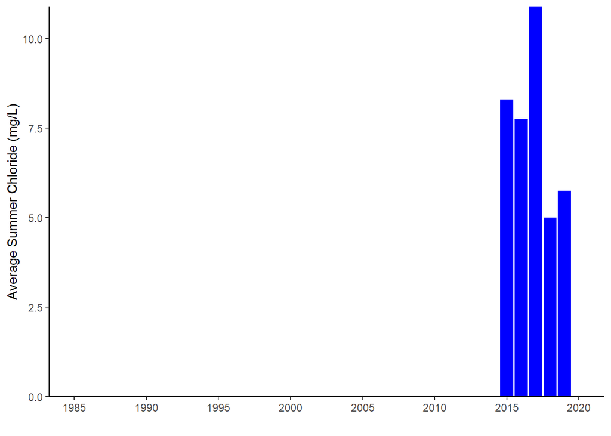

#### Color

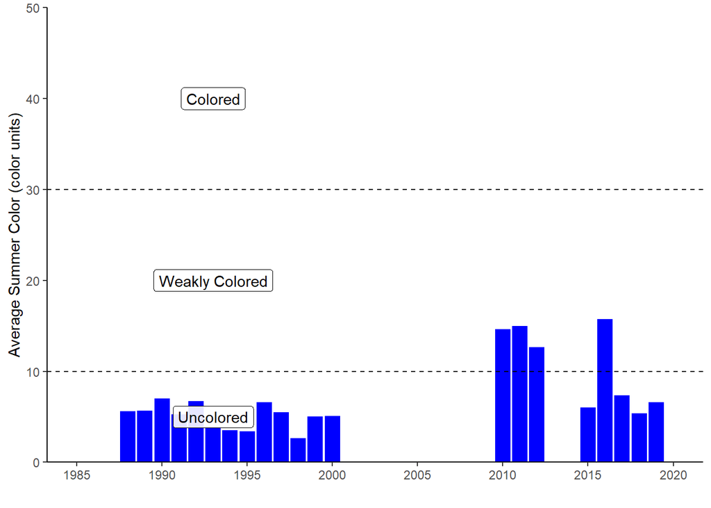

#### Surface and Deep Temperature

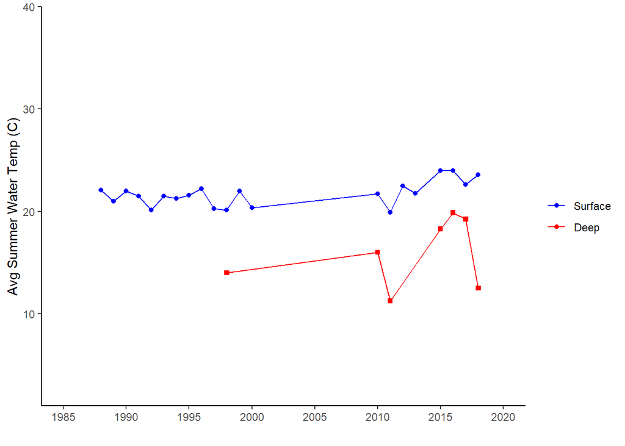

#### Lake Perception

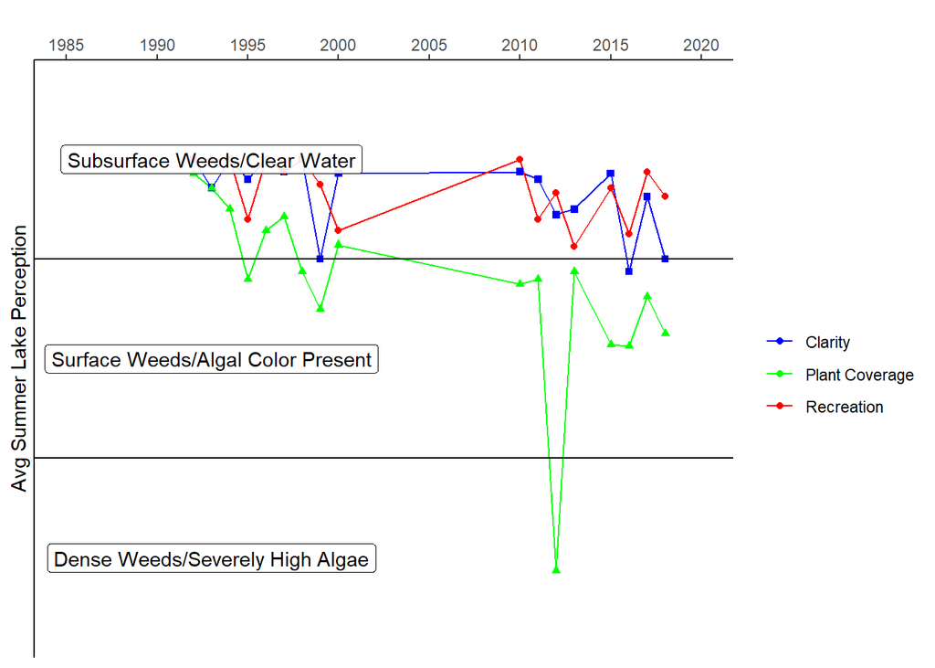

## Eaton Brook Reservoir - In-Season Analysis

#### In Season Water Clarity

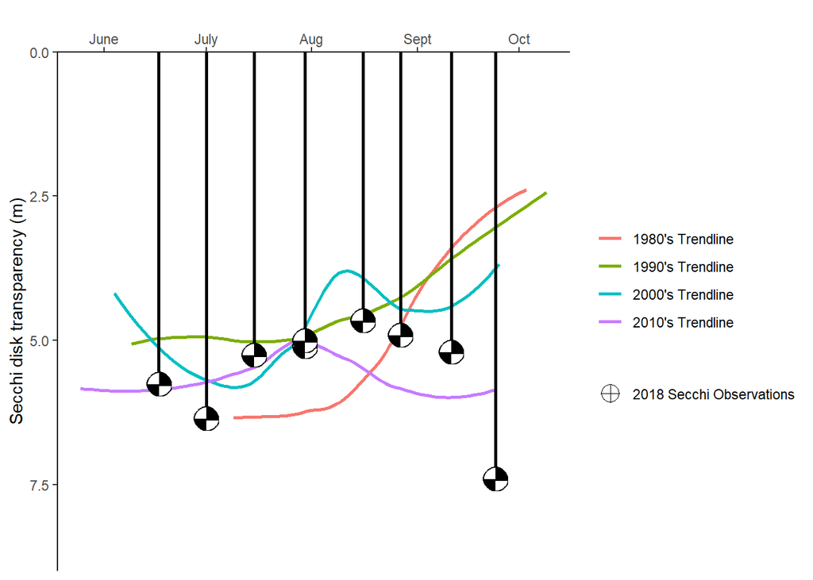

#### In Season Water Temperature

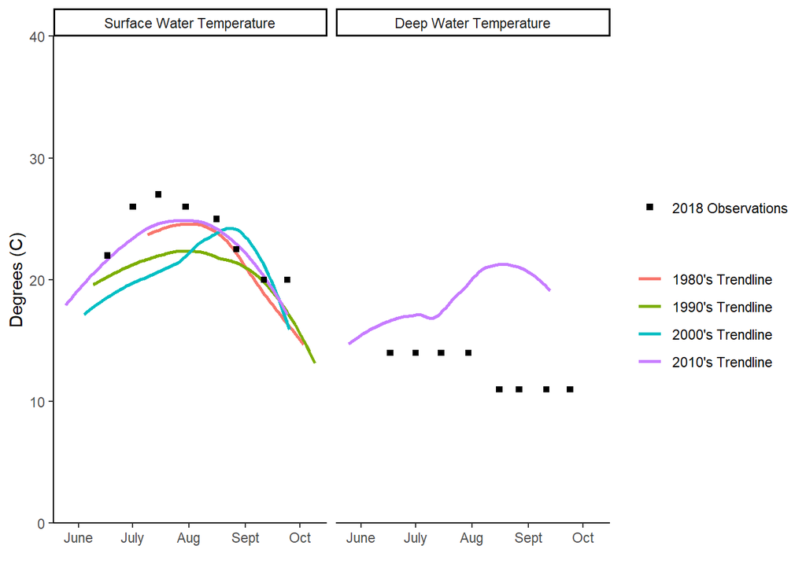